# Bitcoin Pepe - The World's Only Bitcoin Meme ICO

[figure not shown]

## World’s Only Bitcoin Meme ICO

## Presale Live

raised

$1,658,537.2

/

$2,005,500

Stage 3 of 30 - Buy in before price increase!

Current Price: $0.0232

Next Stage Price: $0.0243

#### You receive

Bitcoin Pepe is building Solana on Bitcoin.

• Meme Layer-2 for BTC

• Instant transactions

• Ultra-low fees

• New PEP-20 standard

[figure not shown]

[figure not shown]

## roadmap

#### PHASE1

Spawning

#### PHASE2

L2 Dev Work Begins

#### PHASE3

Presale Live

#### PHASE4

DEX & CEX Listing

#### PHASE5

L2 Bridge Launch

#### PHASE6

DEX Unveil

[figure not shown]

BPEP Returns

1000X

Returns

Time

## how to buy

Buy On Site

Send to Wallet

1

### Connect Your Crypto Wallet

Scroll to the payment widget on the site and click the “Connect Wallet” button. Follow the prompts to link your wallet. Make sure you have sufficient funds to cover both the purchase amount and the network transaction fee for your selected currency (ETH, SOL, USDC, USDT, or BNB).

2

### Select Token and Amount

Choose the currency you wish to use and input the number of BPEP tokens you want to buy. Double-check your wallet balance to ensure it can cover the transaction.

3

### Buy and Approve the Transaction

Confirm your purchase by approving the transaction inside your connected wallet. Once approved, your tokens will be recorded on-chain!

### Tokens

The number of tokens calculated based on the timestamp of your transaction and the price at that time. You will see your wallet balance when you connect the wallet you used to purchase your tokens to the Bitcoin Pepe website.

### Claim

You will be able to claim your tokens at the end of the presale. A complete guide on claiming your tokens will be available on our website.

[figure not shown]

## Tokenomics

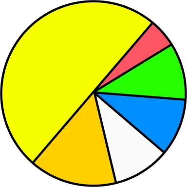

50%

Community

15%

Staking & Rewards

10%

Liquidity

10%

Development

10%

Marketing

5%

Treasury

Stage

Price($)

Increase

Cumulative Gain

Token allocation per stage

1

Sold Out

-

-

20,000,000

2

Sold Out

5.2%

5.2%

35,000,000

3

0.0232

5.0%

10.5%

35,000,000

4

0.0243

4.7%

15.7%

35,000,000

5

0.0255

4.9%

21.4%

35,000,000

6

0.0268

5.1%

27.6%

35,000,000

7

0.0281

4.9%

33.8%

35,000,000

8

0.0295

5.0%

40.5%

35,000,000

9

0.0310

5.1%

47.6%

35,000,000

10

0.0326

5.2%

55.2%

35,000,000

11

0.0342

4.9%

62.9%

35,000,000

12

0.0359

5.0%

71.0%

35,000,000

13

0.0377

5.0%

79.5%

35,000,000

14

0.0396

5.0%

88.6%

35,000,000

15

0.0416

5.1%

98.1%

35,000,000

16

0.0437

5.0%

108.1%

35,000,000

17

0.0458

4.8%

118.1%

35,000,000

18

0.0481

5.0%

129.0%

35,000,000

19

0.0505

5.0%

140.5%

35,000,000

20

0.0531

5.1%

152.9%

35,000,000

21

0.0557

4.9%

165.2%

35,000,000

22

0.0585

5.0%

178.6%

35,000,000

23

0.0614

5.0%

192.4%

35,000,000

24

0.0645

5.0%

207.1%

35,000,000

25

0.0677

5.0%

222.4%

35,000,000

26

0.0711

5.0%

238.6%

35,000,000

27

0.0747

5.1%

255.7%

35,000,000

28

0.0784

5.0%

273.3%

35,000,000

29

0.0823

5.0%

291.9%

35,000,000

30

0.0864

5.0%

311.4%

50,000,000

[figure not shown]

## 1,000,000 $BPEP

## Weekly Giveaway 🚨

Every week, we're giving away a massive 1,000,000 $BPEP tokens to our community! 🐸💥

It’s simple: Get involved, stay active, and you could be one of the lucky frogs hopping away with a huge stack of $BPEP. No gimmicks, just pure action. 💸🔥

Join the chaos, frens. The more you participate, the higher your chances! 🐸🚀

## Meet The Team

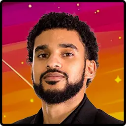

### Nate Sherrod

#### Head Of Community

Nate Sherrod is a web3 veteran with a proven track record of social media & community management, developing partnerships, and launching growth campaigns for projects including Wildxyz, Sphynx Labs, Palm NFT Studio, & DC Comics Bat Cowls.

Now, he's bringing his expertise in community leadership to Bitcoin Pepe. A firm believer in both Bitcoin and the power of memes, Nate is excited to join the team building the first-ever DEX for the Bitcoin ecosystem. He's committed to being a valuable resource for the community and spreading positive $BPEP vibes!

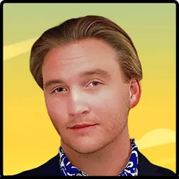

### Collin Ford

#### Technical Advisor

Collin Ford is a generational web3 leader with exceptional talent in bringing visionary ideas to life known for his executive work, consulting and oversight of 100+ startups since 2015 including several brands such as DexToro, My Lil Gnomie NFT, ElevenThirteen Apps and beyond. With a burning passion for intriguing 21st century technology - he looks to bring his years of experience to accelerate the wide stream adoption of everything Bitcoin Pepe has to offer to the World.

Copyright © 2025 Bitcoin Pepe. All Rights Reserved.

[interactive chart not shown]